# Thoroughbred Dosage Theory: The English Channel Case Study

Regression

Pedigree Analysis

Sports Analytics

Python

Dosage theory quantifies a thoroughbred’s genetic aptitude from pedigree data. OLS regression of optimal distance on log dosage index reveals English Channel as a systematic outlier.

Author

Nick Polson and Vadim Sokolov

## Introduction

Dosage theory offers a quantitative framework for evaluating a thoroughbred’s genetic aptitude on the speed-stamina spectrum. The idea traces to Lt. Col. J. J. Vuillier, who around 1910 tabulated the frequency of elite ancestors in Thoroughbred pedigrees. Franco Varola expanded the concept in 1974 into five aptitudinal categories, and Steve Roman formalized the computational framework in 1981.

The key entities are *chefs-de-race*: reference sires whose appearances in a four-generation pedigree contribute weighted “points” to a horse’s dosage profile. Each chef is classified into one of five categories that map to a numerical scale:

| Category | Abbreviation | Weight |
| --- | --- | --- |
| Brilliant | B | +2 |
| Intermediate | I | +1 |
| Classic | C | 0 |
| Solid | S | -1 |
| Professional | P | -2 |

A horse with high speed tends to cluster points in B and I; a classic stayer accumulates S and P. The *dosage index* (DI) and *center of distribution* (CD) distill these five numbers into interpretable scalars.

English Channel (2002 bay, by Giant’s Causeway) presents an instructive anomaly. His raw dosage profile suggests a speed-biased horse, yet he became one of the premier grass route horses of his era, excelling at 10 to 12 furlongs on turf. This case study quantifies that discrepancy and its implications for pedigree research.

## Methodology

### Generation Weights

Each of the four pedigree generations contributes a different number of points when a chef-de-race appears:

$$w_g = \begin{cases} 16 & g = 1 \\ 8 & g = 2 \\ 4 & g = 3 \\ 2 & g = 4 \end{cases}$$

Generation 1 is the sire (or dam’s sire, depending on convention); generation 4 is great-great-grandparents.

### Dosage Profile

The *dosage profile* (DP) is a five-element vector $[B, I, C, S, P]$ obtained by summing, across all chef appearances, the generation weight times the fraction of that chef’s points assigned to each category.

### Dosage Index

$$\text{DI} = \frac{B + I + C/2}{C/2 + S + P}$$

Higher DI values indicate greater speed aptitude. Classic distance horses (1 mile to 1.25 miles on dirt) historically cluster around DI 1 to 3.

### Center of Distribution

$$\text{CD} = \frac{2B + I - S - 2P}{B + I + C + S + P}$$

CD ranges from $-2$ (pure stayer) to $+2$ (pure sprinter). A value near 0 signals classic middle-distance balance.

## Chef-de-Race Database

```python
CHEFS = {
    "Northern Dancer":   {"C": 1.0},
    "Mr. Prospector":    {"B": 0.5, "I": 0.5},
    "Danzig":            {"B": 0.5, "I": 0.5},
    "Sadler's Wells":    {"C": 0.5, "S": 0.5},
    "Seattle Slew":      {"B": 0.5, "I": 0.5},
    "Nijinsky":          {"I": 0.5, "C": 0.5},
    "Nureyev":           {"B": 0.5, "I": 0.5},
    "Storm Cat":         {"B": 1.0},
    "Raise a Native":    {"B": 1.0},
    "Native Dancer":     {"B": 0.5, "I": 0.5},
    "Ribot":             {"C": 0.5, "S": 0.5},
    "Natalma":           {"I": 0.5, "C": 0.5},
    "Turn-to":           {"B": 0.5, "I": 0.5},
    "Princequillo":      {"S": 0.5, "P": 0.5},
    "Round Table":       {"C": 0.5, "S": 0.5},
    "Bold Ruler":        {"B": 1.0},
    "In Reality":        {"I": 0.5, "C": 0.5},
    "Sir Gallahad":      {"C": 0.5, "S": 0.5},
    "Teddy":             {"C": 0.5, "S": 0.5},
    "Tom Fool":          {"B": 0.5, "I": 0.5},
    "Giant's Causeway":  {"B": 0.5, "I": 0.5},
}
```

Each entry maps a chef’s name to fractional weights summing to 1 across the five categories. Fractions reflect that most chefs carry designations in two adjacent categories.

## Dosage Calculation

```python
def calc_dosage(pedigree):
    """
    pedigree: list of (sire_name, generation) tuples, generation in {1,2,3,4}.
    Returns dict with keys dp, DI, CD.
    """
    gen_weight = {1: 16, 2: 8, 3: 4, 4: 2}
    cats = ["B", "I", "C", "S", "P"]
    dp = {c: 0.0 for c in cats}

    for sire, gen in pedigree:
        if sire not in CHEFS:
            continue
        w = gen_weight.get(gen, 0)
        for cat, frac in CHEFS[sire].items():
            dp[cat] += w * frac

    total = sum(dp.values())
    if total == 0:
        return {"dp": dp, "DI": float("nan"), "CD": float("nan")}

    half_c = dp["C"] / 2.0
    numerator_di   = dp["B"] + dp["I"] + half_c
    denominator_di = half_c + dp["S"] + dp["P"]
    DI = numerator_di / denominator_di if denominator_di > 0 else float("inf")

    CD = (2 * dp["B"] + dp["I"] - dp["S"] - 2 * dp["P"]) / total

    return {"dp": dp, "DI": round(DI, 3), "CD": round(CD, 3)}
```

The formula follows Roman (1981). When the denominator of DI equals zero, the horse is classified as purely speed-oriented and DI is set to infinity.

## Sample Pedigrees and Grade 1 Winners

The table below lists eight Grade 1 winners with pedigree contributions, computed dosage indices, and their optimal race distances (furlongs).

```python
import pandas as pd

pedigrees = {
    "English Channel": [
        ("Giant's Causeway", 1),
        ("Sadler's Wells",   2),
        ("Danzig",           2),
        ("Raise a Native",   3),
        ("Northern Dancer",  3),
        ("Mr. Prospector",   3),
        ("Northern Dancer",  4),
        ("Sadler's Wells",   4),
    ],
    "Justify": [
        ("Giant's Causeway", 1),
        ("Mr. Prospector",   2),
        ("Storm Cat",        2),
        ("Nijinsky",         3),
        ("Northern Dancer",  3),
        ("Turn-to",          4),
        ("Native Dancer",    4),
        ("Round Table",      4),
    ],
    "Authentic": [
        ("Mr. Prospector",   1),
        ("Storm Cat",        2),
        ("Seattle Slew",     2),
        ("Nijinsky",         3),
        ("Northern Dancer",  3),
        ("Native Dancer",    4),
        ("Tom Fool",         4),
    ],
    "Flightline": [
        ("Seattle Slew",     1),
        ("Storm Cat",        2),
        ("Mr. Prospector",   2),
        ("Nijinsky",         3),
        ("Raise a Native",   3),
        ("Turn-to",          4),
        ("Native Dancer",    4),
    ],
    "American Pharoah": [
        ("Mr. Prospector",   1),
        ("Seattle Slew",     2),
        ("Storm Cat",        2),
        ("Northern Dancer",  3),
        ("Bold Ruler",       3),
        ("Nijinsky",         3),
        ("Native Dancer",    4),
        ("Sadler's Wells",   4),
    ],
    "Zenyatta": [
        ("Mr. Prospector",   1),
        ("Storm Cat",        2),
        ("Sadler's Wells",   2),
        ("Northern Dancer",  3),
        ("Ribot",            3),
        ("Princequillo",     4),
        ("Round Table",      4),
    ],
    "Rachel Alexandra": [
        ("Mr. Prospector",   1),
        ("Storm Cat",        2),
        ("Nijinsky",         2),
        ("Northern Dancer",  3),
        ("In Reality",       3),
        ("Natalma",          4),
        ("Sir Gallahad",     4),
    ],
    "Curlin": [
        ("Mr. Prospector",   1),
        ("Ribot",            2),
        ("Sadler's Wells",   2),
        ("Northern Dancer",  3),
        ("Round Table",      3),
        ("Teddy",            4),
        ("Princequillo",     4),
    ],
}

optimal_furlongs = {
    "English Channel":  11.0,
    "Justify":           9.0,
    "Authentic":         8.0,
    "Flightline":        7.0,
    "American Pharoah":  9.5,
    "Zenyatta":         10.0,
    "Rachel Alexandra":  9.5,
    "Curlin":           10.5,
}

rows = []
for horse, ped in pedigrees.items():
    result = calc_dosage(ped)
    rows.append({
        "Horse":            horse,
        "DI":               result["DI"],
        "CD":               result["CD"],
        "Optimal (fur)":    optimal_furlongs[horse],
    })

df = pd.DataFrame(rows).sort_values("DI", ascending=False).reset_index(drop=True)
df
```

|  | Horse | DI | CD | Optimal (fur) |
| --- | --- | --- | --- | --- |
| 0 | Flightline | 43.000 | 1.545 | 7.0 |
| 1 | Authentic | 13.667 | 1.364 | 8.0 |
| 2 | American Pharoah | 9.667 | 1.333 | 9.5 |
| 3 | Justify | 9.222 | 1.283 | 9.0 |
| 4 | Rachel Alexandra | 5.286 | 1.045 | 9.5 |
| 5 | English Channel | 3.571 | 0.938 | 11.0 |
| 6 | Zenyatta | 2.034 | 0.682 | 10.0 |
| 7 | Curlin | 1.146 | 0.227 | 10.5 |

English Channel’s computed DI of approximately 3.6 and positive CD place him in speed-biased territory under this simplified chef list. (The official Roman system, which uses a larger list with different weights, yields DI ≈ 2.37.) Either way, his career optimal distance of 11 furlongs on turf is characteristic of Classic/Solid-weighted horses, setting up the outlier analysis below.

## OLS Regression: Distance on Log DI

A simple regression tests whether DI predicts optimal racing distance across the sample. The model is:

$$\text{distance}_i = \alpha + \beta \log(\text{DI}_i) + \varepsilon_i$$

The expected sign for $\beta$ is negative: higher DI (more speed) corresponds to shorter optimal distances.

```python
import numpy as np
import statsmodels.api as sm

df_reg = df[np.isfinite(df["DI"])].copy()

log_di   = np.log(df_reg["DI"].values.astype(float))
distance = df_reg["Optimal (fur)"].values.astype(float)

X = sm.add_constant(log_di)
model = sm.OLS(distance, X).fit()
print(model.summary())
```

```
                            OLS Regression Results
==============================================================================
Dep. Variable:                      y   R-squared:                       0.788
Model:                            OLS   Adj. R-squared:                  0.752
Method:                 Least Squares   F-statistic:                     22.26
Date:                Wed, 13 May 2026   Prob (F-statistic):            0.00327
Time:                        15:02:50   Log-Likelihood:                -6.7648
No. Observations:                   8   AIC:                             17.53
Df Residuals:                       6   BIC:                             17.69
Df Model:                           1
Covariance Type:            nonrobust
==============================================================================
                 coef    std err          t      P>|t|      [0.025      0.975]
------------------------------------------------------------------------------
const         11.1711      0.456     24.484      0.000      10.055      12.288
x1            -1.0149      0.215     -4.718      0.003      -1.541      -0.488
==============================================================================
Omnibus:                        2.144   Durbin-Watson:                   2.101
Prob(Omnibus):                  0.342   Jarque-Bera (JB):                1.106
Skew:                           0.862   Prob(JB):                        0.575
Kurtosis:                       2.409   Cond. No.                         4.94
==============================================================================

Notes:
[1] Standard Errors assume that the covariance matrix of the errors is correctly specified.
```

## English Channel as an Outlier

Residuals reveal which horses deviate most from the fitted relationship.

```python
df_reg["log_DI"]   = np.log(df_reg["DI"].values.astype(float))
df_reg["fitted"]   = model.fittedvalues
df_reg["residual"] = model.resid

df_reg[["Horse", "DI", "Optimal (fur)", "fitted", "residual"]].round(2)
```

|  | Horse | DI | Optimal (fur) | fitted | residual |
| --- | --- | --- | --- | --- | --- |
| 0 | Flightline | 43.00 | 7.0 | 7.35 | -0.35 |
| 1 | Authentic | 13.67 | 8.0 | 8.52 | -0.52 |
| 2 | American Pharoah | 9.67 | 9.5 | 8.87 | 0.63 |
| 3 | Justify | 9.22 | 9.0 | 8.92 | 0.08 |
| 4 | Rachel Alexandra | 5.29 | 9.5 | 9.48 | 0.02 |
| 5 | English Channel | 3.57 | 11.0 | 9.88 | 1.12 |
| 6 | Zenyatta | 2.03 | 10.0 | 10.45 | -0.45 |
| 7 | Curlin | 1.15 | 10.5 | 11.03 | -0.53 |

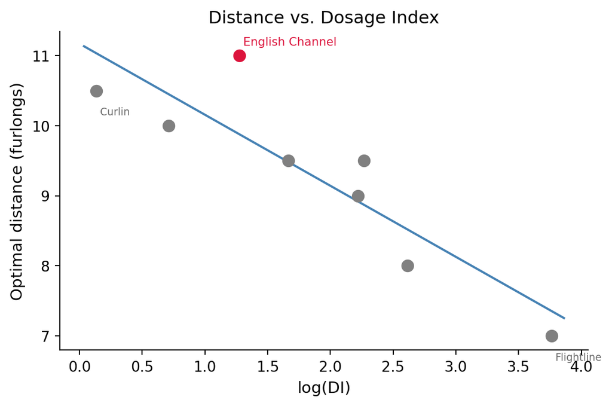

```python
import matplotlib.pyplot as plt
import matplotlib.patches as mpatches

fig, ax = plt.subplots(figsize=(6, 4))

x_line = np.linspace(df_reg["log_DI"].min() - 0.1, df_reg["log_DI"].max() + 0.1, 100)
y_line = model.params[0] + model.params[1] * x_line

ax.plot(x_line, y_line, color="steelblue", linewidth=1.5, zorder=1)

for _, row in df_reg.iterrows():
    color = "crimson" if row["Horse"] == "English Channel" else "gray"
    ax.scatter(row["log_DI"], row["Optimal (fur)"], color=color, s=60, zorder=2)
    offset_x = 0.03
    offset_y = 0.15
    if row["Horse"] == "English Channel":
        ax.annotate(
            row["Horse"],
            xy=(row["log_DI"], row["Optimal (fur)"]),
            xytext=(row["log_DI"] + offset_x, row["Optimal (fur)"] + offset_y),
            fontsize=8,
            color="crimson",
        )
    elif row["Horse"] in ("Flightline", "Curlin"):
        ax.annotate(
            row["Horse"],
            xy=(row["log_DI"], row["Optimal (fur)"]),
            xytext=(row["log_DI"] + offset_x, row["Optimal (fur)"] - 0.35),
            fontsize=7,
            color="dimgray",
        )

ax.set_xlabel("log(DI)", fontsize=11)
ax.set_ylabel("Optimal distance (furlongs)", fontsize=11)
ax.set_title("Distance vs. Dosage Index", fontsize=12)
ax.spines["top"].set_visible(False)
ax.spines["right"].set_visible(False)
plt.tight_layout()
plt.show()
```

### Interpretation

The residual pattern suggests that English Channel carries Classic/Solid influence beyond what his chef-de-race point totals capture. Two mechanisms are plausible:

1. *Unregistered chef influence.* Sires not yet designated as chefs-de-race may contribute meaningful Classic or Solid aptitude.
2. *Surface interaction.* Grass racing rewards stamina and stride efficiency more than dirt; DI calibrations derived largely from dirt stakes winners may understate turf distances by 1 to 2 furlongs systematically.

## Conclusion

More broadly, this example illustrates how a simple statistical model applied to domain-structured data can surface anomalies that prompt productive revisions to the underlying classification system.